# Part II - (Ford GoBike System Data)

## by (Richard Oloyede)

## Investigation Overview

In this investigation, I wanted to know what time of the day had the most ride, what day of the week had the most ride and also understand the charateristics features/variables that affect the Bike ride duration

## Dataset Overview

The Ford GoBike System Data contains 20 features ('duration_sec','start_time','end_time','start_station_id','start_station_name','end_station_id','end_station_name','bike_id','user_type','member_birth_year', 'member_gender','bike_share_for_all_trip') and other with 183,412 datapoint for individauls in a bike-sharing system covering the greater San Francisco Bay area.for the month of Feburary 2019

## Distribution of Bike Ride Duration

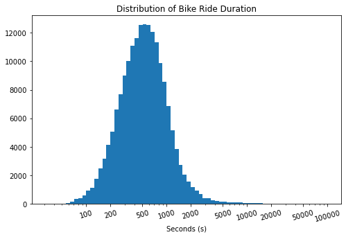

## Distribution of Bike Ride Start Time

The distribution of the hours individual started the bike ride looks bimodal with the hours 8:00 and 17:00 being the most time individual start their bike,which correspond to the time individual go to work and finish from work,while the hours between 0:00 and 5:00 getting the lowest frequency of time which expected. The hours 10:00 to 16:00 getting an average frequency of time people borrow bikes which is also expected as its usually working hours

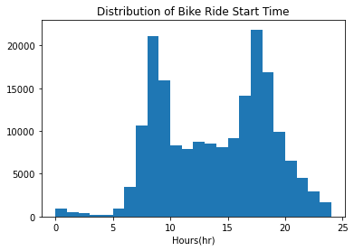

## When is the most trips taken in terms of Days of the week?

The plot above reveals that the highest day an individual rider books a ride is **Thursday**

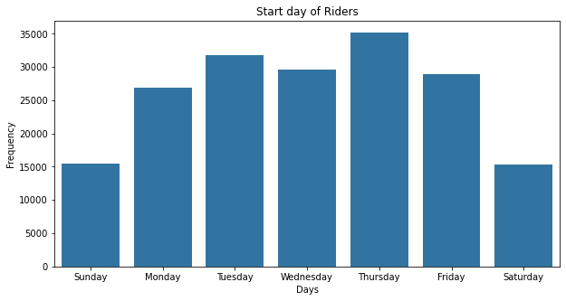

## Bike Ride Duration by (User type, Gender ,Bike Share)

There appears the be a positive correlation between the duration time and the user type. while there is no relation between the duration time and the members gender or if the member shares a bike ride or not.

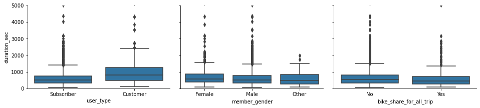

## Bike Ride Duration by (Days of the week Ride started and ended)

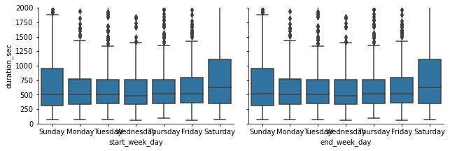

## Bike Ride Duration by Age and User Type

The above plot depecits majority of lower ride duration in between customer and subscriber in the most in the 20's-60's age range.

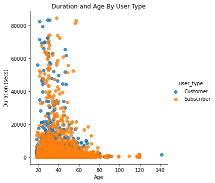